# Project2_lm

unknown

07 12 2019

Открываем датасет Boston

```r
library(MASS)
Boston <- MASS::Boston
str(Boston)
```

```
## 'data.frame':    506 obs. of  14 variables:
##  $ crim   : num  0.00632 0.02731 0.02729 0.03237 0.06905 ...
##  $ zn     : num  18 0 0 0 0 0 12.5 12.5 12.5 12.5 ...
##  $ indus  : num  2.31 7.07 7.07 2.18 2.18 2.18 7.87 7.87 7.87 7.87 ...
##  $ chas   : int  0 0 0 0 0 0 0 0 0 0 ...
##  $ nox    : num  0.538 0.469 0.469 0.458 0.458 0.458 0.524 0.524 0.524 0.524 ...
##  $ rm     : num  6.58 6.42 7.18 7 7.15 ...
##  $ age    : num  65.2 78.9 61.1 45.8 54.2 58.7 66.6 96.1 100 85.9 ...
##  $ dis    : num  4.09 4.97 4.97 6.06 6.06 ...
##  $ rad    : int  1 2 2 3 3 3 5 5 5 5 ...
##  $ tax    : num  296 242 242 222 222 222 311 311 311 311 ...
##  $ ptratio: num  15.3 17.8 17.8 18.7 18.7 18.7 15.2 15.2 15.2 15.2 ...
##  $ black  : num  397 397 393 395 397 ...
##  $ lstat  : num  4.98 9.14 4.03 2.94 5.33 ...
##  $ medv   : num  24 21.6 34.7 33.4 36.2 28.7 22.9 27.1 16.5 18.9 ...
```

Видим, что значения двух переменных - дискретны. Нам нужно провести **стандартизацию**, но стандартизации не подлежат дискретные переменные (chas,rad), а также не будем делать стандартизацию зависимой переменной, поэтому выделяем для scale соответствующие колонки.Перед этим предварительно переводим chas и rad в факторные.

## Построение полной модели

```r
Boston_scale <- Boston
Boston_scale$chas <- as.factor(Boston_scale$chas)
Boston_scale$rad <- as.factor(Boston_scale$rad)
Boston_scale[,c(-4,-9,-14)]<- scale(Boston_scale[,c(-4,-9,-14)])
```

Внешне оценим наличие **корреляций** между предикторами.

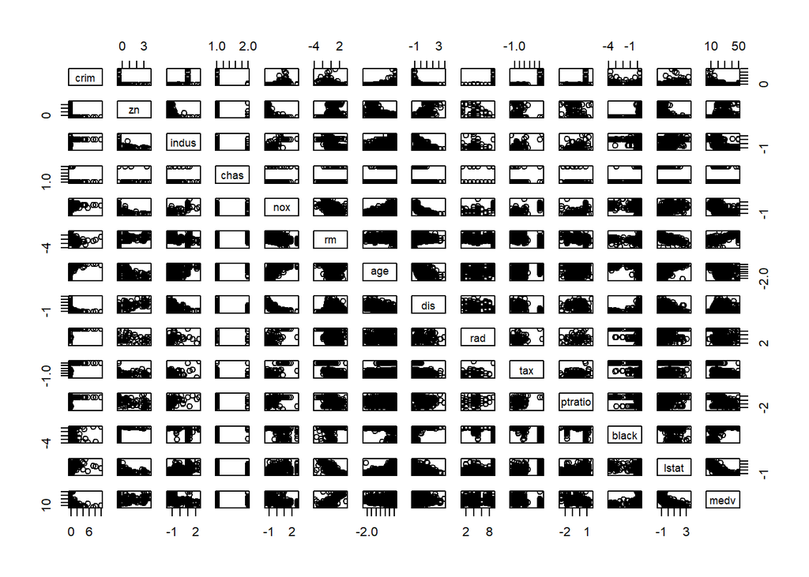

```r
pairs(Boston_scale)
```

Между некоторыми предикторами она есть, значит дальше нам точно необходимо будет проводить проверку на мультиколлинеарность.

Построим **полную линейную модель** для medv, учитывая все предикторы.

```r
bos_new <- lm(medv~lstat+black+ptratio+tax+rad+dis+age+rm+nox+chas+indus+zn+crim,data=Boston_scale)
summary(bos_new)
```

```
##
## Call:
## lm(formula = medv ~ lstat + black + ptratio + tax + rad + dis +
##     age + rm + nox + chas + indus + zn + crim, data = Boston_scale)
##
## Residuals:
##      Min       1Q   Median       3Q      Max
## -15.1020  -2.7355  -0.4565   1.6821  25.9450
##
## Coefficients:
##             Estimate Std. Error t value Pr(>|t|)
## (Intercept) 18.31176    1.15474  15.858  < 2e-16 ***
## lstat       -3.77923    0.36162 -10.451  < 2e-16 ***
## black        0.85761    0.24291   3.531 0.000454 ***
## ptratio     -2.10523    0.31279  -6.731 4.78e-11 ***
## tax         -1.47439    0.65641  -2.246 0.025144 *
## rad2         1.48891    1.47751   1.008 0.314095
## rad3         4.68125    1.33530   3.506 0.000498 ***
## rad4         2.57623    1.18737   2.170 0.030514 *
## rad5         2.91849    1.20761   2.417 0.016028 *
## rad6         1.18584    1.46401   0.810 0.418342
## rad7         4.87899    1.57120   3.105 0.002012 **
## rad8         4.83984    1.49166   3.245 0.001257 **
## rad24        7.46167    1.78868   4.172 3.58e-05 ***
## dis         -3.27342    0.42516  -7.699 7.75e-14 ***
## age          0.01298    0.37232   0.035 0.972210
## rm           2.57544    0.29594   8.703  < 2e-16 ***
## nox         -2.03633    0.45150  -4.510 8.13e-06 ***
## chas1        2.52416    0.86318   2.924 0.003614 **
## indus        0.16300    0.43665   0.373 0.709081
## zn           1.28032    0.32999   3.880 0.000119 ***
## crim        -0.93603    0.28114  -3.329 0.000937 ***
## ---
## Signif. codes:  0 '***' 0.001 '**' 0.01 '*' 0.05 '.' 0.1 ' ' 1
##
## Residual standard error: 4.694 on 485 degrees of freedom
## Multiple R-squared:  0.7499, Adjusted R-squared:  0.7396
## F-statistic:  72.7 on 20 and 485 DF,  p-value: < 2.2e-16
```

Построим **график остатков**, от предсказанных значений, чтобы оценить **линейности взаимосвязи** и **постоянство дисперсии**.

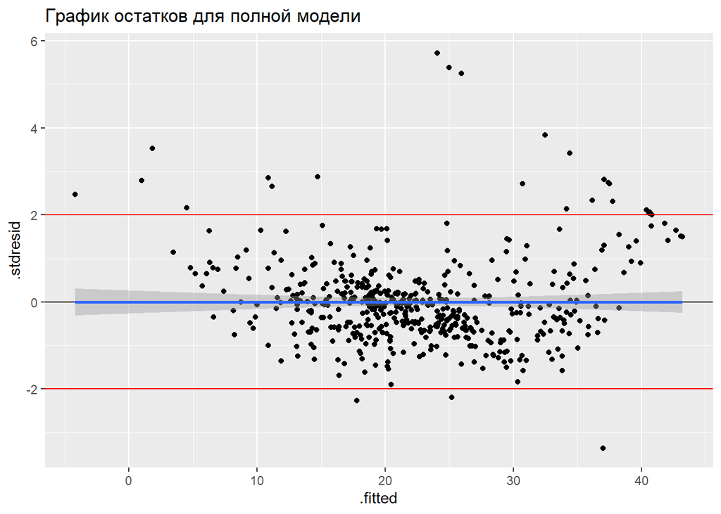

```r
bos_new_for <- data.frame(fortify(bos_new))
gg_resid <- ggplot(data = bos_new_for, aes(x = .fitted, y = .stdresid)) +
  geom_point() +
  geom_hline(yintercept = 0) +
  geom_smooth(method = "lm") +
  geom_hline(yintercept = 2, color = "red") +
  geom_hline(yintercept = -2, color = "red") +
  ggtitle("График остатков для полной модели")
gg_resid
```

Дисперсия остатков довольно постоянная, а вот с линейностью наблюдаем проблемы : в начале и в конце больше положительных значений, в середине - отрицательных.

Также построим для данной модели **график расстояний Кука**, чтобы оценить наличие влиятельных наблюдений.

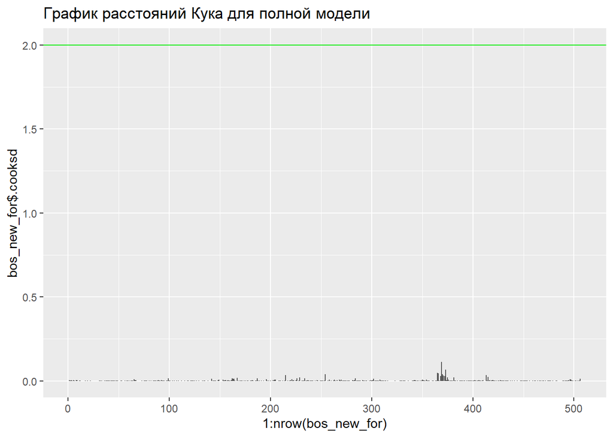

```r
ggplot(, aes(x = 1:nrow(bos_new_for), y = bos_new_for$.cooksd)) +
  geom_bar(stat = "identity") +
  geom_hline(yintercept = 2, color = "green2") + ggtitle("График расстояний Кука для полной модели")
```

Для оценки нормальности остатков построим **QQ-Plot**

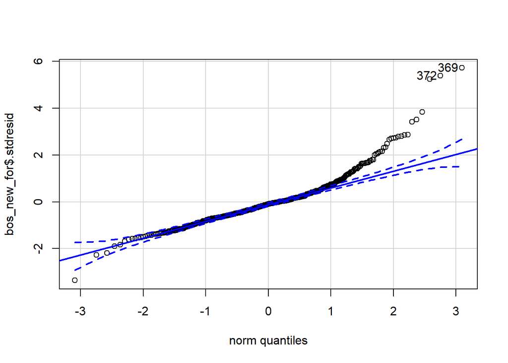

```
## [1] 369 372
```

```r
qqPlot(bos_new_for$.stdresid)
```

Наши максимальные значения слишком высоки для нормального распределения. В целом, диагностика модели показывает, что она плохая. Но график предсказанных значений мы все же построим.

Для начала посмотрим на коэффициенты.

```r
 summary(bos_new)
```

```
##
## Call:
## lm(formula = medv ~ lstat + black + ptratio + tax + rad + dis +
##     age + rm + nox + chas + indus + zn + crim, data = Boston_scale)
##
## Residuals:
##      Min       1Q   Median       3Q      Max
## -15.1020  -2.7355  -0.4565   1.6821  25.9450
##
## Coefficients:
##             Estimate Std. Error t value Pr(>|t|)
## (Intercept) 18.31176    1.15474  15.858  < 2e-16 ***
## lstat       -3.77923    0.36162 -10.451  < 2e-16 ***
## black        0.85761    0.24291   3.531 0.000454 ***
## ptratio     -2.10523    0.31279  -6.731 4.78e-11 ***
## tax         -1.47439    0.65641  -2.246 0.025144 *
## rad2         1.48891    1.47751   1.008 0.314095
## rad3         4.68125    1.33530   3.506 0.000498 ***
## rad4         2.57623    1.18737   2.170 0.030514 *
## rad5         2.91849    1.20761   2.417 0.016028 *
## rad6         1.18584    1.46401   0.810 0.418342
## rad7         4.87899    1.57120   3.105 0.002012 **
## rad8         4.83984    1.49166   3.245 0.001257 **
## rad24        7.46167    1.78868   4.172 3.58e-05 ***
## dis         -3.27342    0.42516  -7.699 7.75e-14 ***
## age          0.01298    0.37232   0.035 0.972210
## rm           2.57544    0.29594   8.703  < 2e-16 ***
## nox         -2.03633    0.45150  -4.510 8.13e-06 ***
## chas1        2.52416    0.86318   2.924 0.003614 **
## indus        0.16300    0.43665   0.373 0.709081
## zn           1.28032    0.32999   3.880 0.000119 ***
## crim        -0.93603    0.28114  -3.329 0.000937 ***
## ---
## Signif. codes:  0 '***' 0.001 '**' 0.01 '*' 0.05 '.' 0.1 ' ' 1
##
## Residual standard error: 4.694 on 485 degrees of freedom
## Multiple R-squared:  0.7499, Adjusted R-squared:  0.7396
## F-statistic:  72.7 on 20 and 485 DF,  p-value: < 2.2e-16
```

Видим, что наибольший коэффициент у предиктора rad.

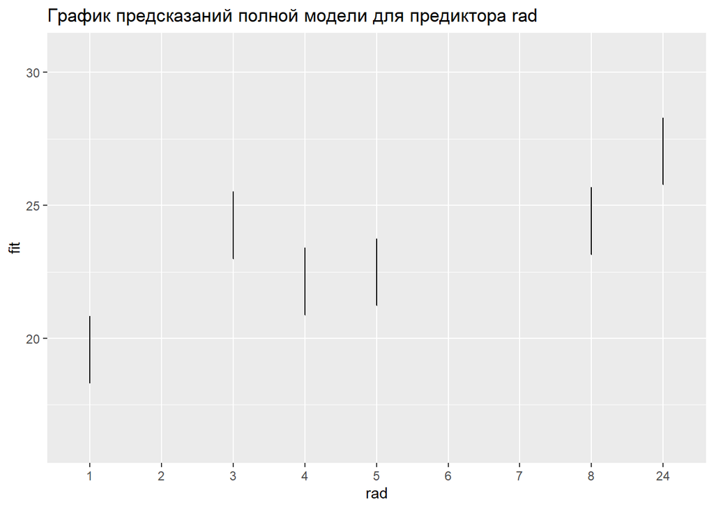

```r
MyData <- data.frame(
     rad = (Boston_scale$rad),
     crim = mean(Boston_scale$crim),
     zn = mean(Boston_scale$zn),
     chas = Boston_scale$chas,
     nox = mean(Boston_scale$nox),
     rm = mean(Boston_scale$rm),
     age = mean(Boston_scale$age),
     dis = mean(Boston_scale$dis),
     tax = mean(Boston_scale$tax),
     ptratio = mean(Boston_scale$ptratio),
     black = mean(Boston_scale$black),
     lstat = mean(Boston_scale$lstat),
     indus = mean(Boston_scale$indus))

Predictions <- predict(bos_new, newdata = MyData,  interval = 'confidence')
MyData <- data.frame(MyData, Predictions)

Pl_predict <- ggplot(MyData, aes(x = rad, y = fit)) +
  geom_ribbon(alpha = 0.2, aes(ymin = lwr, ymax = upr)) +
  geom_line() +
  ggtitle("График предсказаний полной модели для предиктора rad")
Pl_predict
```

## Приступим к подбору улучшенной линейной модели

```r
vif(bos_new)
```

```
##              GVIF Df GVIF^(1/(2*Df))
## lstat    2.997620  1        1.731364
## black    1.352516  1        1.162977
## ptratio  2.242683  1        1.497559
## tax      9.876853  1        3.142746
## rad     18.783126  8        1.201187
## dis      4.143583  1        2.035579
## age      3.177556  1        1.782570
## rm       2.007593  1        1.416896
## nox      4.672906  1        2.161691
## chas     1.101843  1        1.049687
## indus    4.370471  1        2.090567
## zn       2.496184  1        1.579932
## crim     1.811867  1        1.346056
```

```r
bos_2 <- update(bos_new, .~. - rad)
```

Видим, что наибольшим vif для модели bos_new обладает предиктор rad, убираем его.

```r
vif(bos_2)
```

```
##    lstat    black  ptratio      tax      dis      age       rm      nox
## 2.937752 1.341459 1.734873 3.415289 3.954951 3.083009 1.885425 4.304929
##     chas    indus       zn     crim
## 1.061561 3.682265 2.273018 1.664471
```

```r
bos_3 <- update(bos_2, .~. - nox)
```

По той же логике убираем nox

```r
vif(bos_3)
```

```
##    lstat    black  ptratio      tax      dis      age       rm     chas
## 2.921385 1.331479 1.566568 3.095110 3.628870 2.878244 1.875477 1.058946
##    indus       zn     crim
## 3.477127 2.266956 1.663613
```

```r
bos_4 <- update(bos_3, .~. - dis)
```

и dis

```r
vif(bos_4)
```

```
##    lstat    black  ptratio      tax      age       rm     chas    indus
## 2.920516 1.331457 1.504126 3.073277 2.430656 1.847368 1.057774 3.155735
##       zn     crim
## 1.826807 1.637882
```

```r
bos_5 <- update(bos_4, .~. - indus)
```

и indus

```r
vif(bos_5)
```

```
##    lstat    black  ptratio      tax      age       rm     chas       zn
## 2.897706 1.329512 1.499542 2.209662 2.291640 1.813320 1.045869 1.695271
##     crim
## 1.622496
```

```r
bos_6 <- update(bos_5, .~. - lstat)
```

lstat

```r
vif(bos_6)
```

```
##    black  ptratio      tax      age       rm     chas       zn     crim
## 1.291187 1.498101 2.183730 1.861441 1.222973 1.043834 1.692884 1.581361
```

```r
bos_7 <- update(bos_6, .~. - tax)
```

tax

```r
vif(bos_7)
```

```
##    black  ptratio      age       rm     chas       zn     crim
## 1.209887 1.345528 1.668190 1.216701 1.043732 1.680416 1.342583
```

Теперь мы избавились от всех предикторов со значением vif больше 2. Скорее всего, мы выкинули слишком много, но потом мы еще проверим наличие неучтенных взаимосвязей для удаленных предикторов.

А пока посмотрим график остатков.

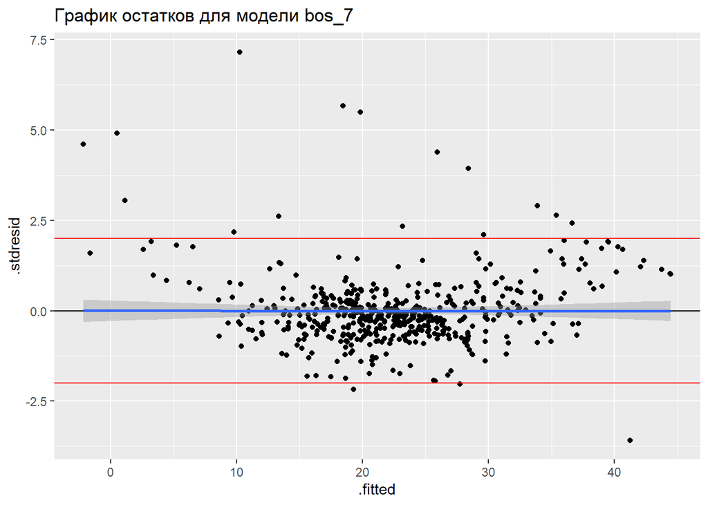

```r
bos_7_for <- data.frame(fortify(bos_7))
gg_resid<- ggplot(data = bos_7_for, aes(x = .fitted, y = .stdresid)) +
  geom_point() +
  geom_hline(yintercept = 0) +
  geom_smooth(method = "lm") +
  geom_hline(yintercept = 2, color = "red") +
  geom_hline(yintercept = -2, color = "red") +
  ggtitle("График остатков для модели bos_7")
gg_resid
```

Удаление предикторов не привело к улучшению.

Теперь проведем отбор значимых предикторов.

```r
drop1(bos_7, test = "F")
```

```
## Single term deletions
##
## Model:
## medv ~ black + ptratio + age + rm + chas + zn + crim
##         Df Sum of Sq   RSS    AIC  F value    Pr(>F)
## <none>               15509 1747.9
## black    1     781.1 16290 1770.7  25.0805 7.646e-07 ***
## ptratio  1    1514.7 17024 1793.0  48.6365 9.843e-12 ***
## age      1     411.9 15921 1759.1  13.2258 0.0003049 ***
## rm       1   10225.3 25735 2002.1 328.3350 < 2.2e-16 ***
## chas     1     386.8 15896 1758.3  12.4206 0.0004638 ***
## zn       1       1.6 15511 1745.9   0.0506 0.8220598
## crim     1     323.2 15832 1756.3  10.3772 0.0013592 **
## ---
## Signif. codes:  0 '***' 0.001 '**' 0.01 '*' 0.05 '.' 0.1 ' ' 1
```

```r
bos_8 <- update(bos_7, .~. - zn)
drop1(bos_8, test = "F")
```

```
## Single term deletions
##
## Model:
## medv ~ black + ptratio + age + rm + chas + crim
##         Df Sum of Sq   RSS    AIC F value    Pr(>F)
## <none>               15511 1745.9
## black    1     780.3 16291 1768.8  25.103 7.559e-07 ***
## ptratio  1    1605.3 17116 1793.7  51.644 2.440e-12 ***
## age      1     514.5 16025 1760.4  16.553 5.498e-05 ***
## rm       1   10413.2 25924 2003.8 335.006 < 2.2e-16 ***
## chas     1     390.0 15901 1756.5  12.546 0.0004342 ***
## crim     1     329.2 15840 1754.5  10.591 0.0012133 **
## ---
## Signif. codes:  0 '***' 0.001 '**' 0.01 '*' 0.05 '.' 0.1 ' ' 1
```

Незначащий предиктор только один - zn. Исключим его. И посмотрим на график остатков.

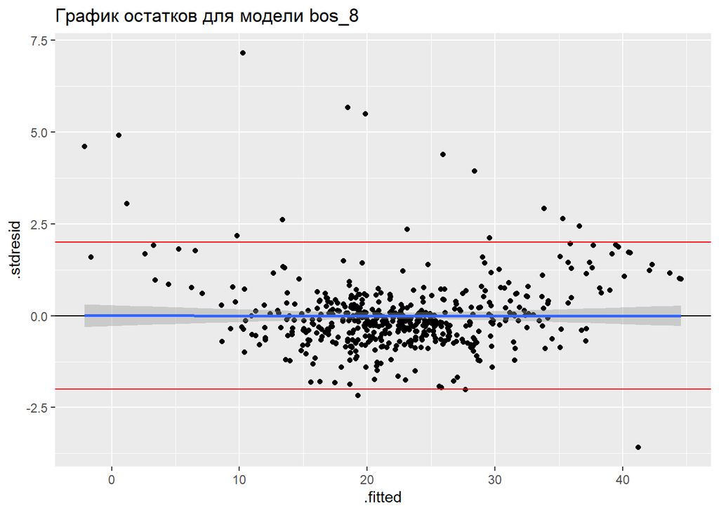

```r
bos_8_for <- data.frame(fortify(bos_8))
gg_resid<- ggplot(data = bos_8_for, aes(x = .fitted, y = .stdresid)) +
  geom_point() +
  geom_hline(yintercept = 0) +
  geom_smooth(method = "lm") +
  geom_hline(yintercept = 2, color = "red") +
  geom_hline(yintercept = -2, color = "red") +
  ggtitle("График остатков для модели bos_8")
gg_resid
```

У модели все равно много недостатков - нелинейность стала еще более выраженной.

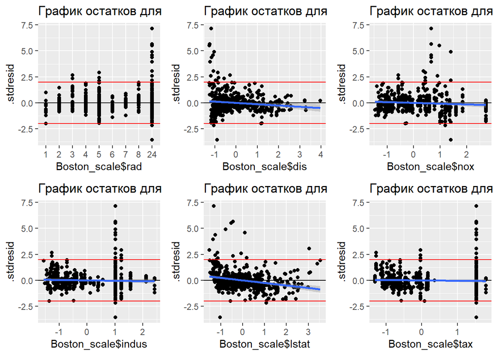

```r
res_1 <- gg_resid + aes(x = Boston_scale$rad)
res_2 <- gg_resid + aes(x = Boston_scale$dis)
res_3 <- gg_resid + aes(x = Boston_scale$nox)
res_4 <- gg_resid + aes(x = Boston_scale$indus)
res_5 <- gg_resid + aes(x = Boston_scale$lstat)
res_6 <- gg_resid + aes(x = Boston_scale$tax)
grid.arrange(res_1, res_2, res_3, res_4,res_5, res_6,nrow = 2)
```

Видим зависимость от переменных lstat и dis, вернем их.

```r
bos_9 <- update(bos_8, .~. +lstat + dis)
drop1(bos_9, test = "F")
```

```
## Single term deletions
##
## Model:
## medv ~ black + ptratio + age + rm + chas + crim + lstat + dis
##         Df Sum of Sq   RSS    AIC  F value    Pr(>F)
## <none>               12298 1632.5
## black    1    364.08 12662 1645.2  14.7137 0.0001412 ***
## ptratio  1   1403.79 13702 1685.2  56.7319 2.375e-13 ***
## age      1    102.94 12401 1634.7   4.1600 0.0419180 *
## rm       1   2956.08 15254 1739.5 119.4652 < 2.2e-16 ***
## chas     1    238.14 12536 1640.2   9.6242 0.0020295 **
## crim     1     99.90 12398 1634.6   4.0372 0.0450489 *
## lstat    1   2639.66 14938 1728.9 106.6775 < 2.2e-16 ***
## dis      1    606.86 12905 1654.8  24.5254 1.007e-06 ***
## ---
## Signif. codes:  0 '***' 0.001 '**' 0.01 '*' 0.05 '.' 0.1 ' ' 1
```

Если снова проверить значимость предикторов - два предиктора находятся совсем на пороге уровня значимости 0,05, так что уберем их тоже.

```r
bos_10 <- update(bos_9, .~.- age - crim)
drop1(bos_10, test = "F")
```

```
## Single term deletions
##
## Model:
## medv ~ black + ptratio + rm + chas + lstat + dis
##         Df Sum of Sq   RSS    AIC  F value    Pr(>F)
## <none>               12495 1636.5
## black    1     466.4 12962 1653.1  18.6260 1.918e-05 ***
## ptratio  1    1581.0 14076 1694.8  63.1371 1.292e-14 ***
## rm       1    2804.1 15299 1737.0 111.9854 < 2.2e-16 ***
## chas     1     231.2 12726 1643.8   9.2325  0.002502 **
## lstat    1    4082.9 16578 1777.6 163.0538 < 2.2e-16 ***
## dis      1     491.0 12986 1654.0  19.6079 1.169e-05 ***
## ---
## Signif. codes:  0 '***' 0.001 '**' 0.01 '*' 0.05 '.' 0.1 ' ' 1
```

Построим график остатков, чтобы оценить линейность связи и дисперсию остатков.

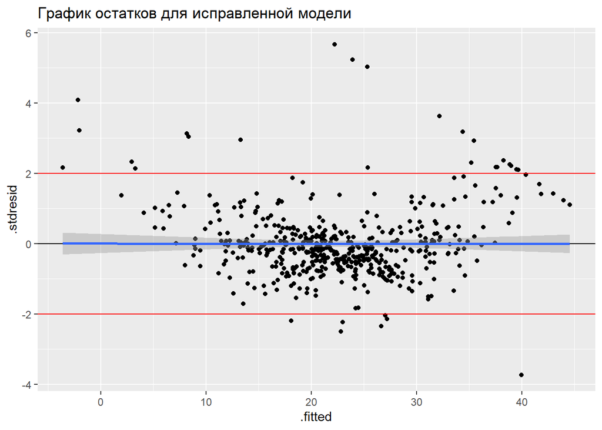

```r
bos_10_for <- data.frame(fortify(bos_10))
gg_resid<- ggplot(data = bos_10_for, aes(x = .fitted, y = .stdresid)) +
  geom_point() +
  geom_hline(yintercept = 0) +
  geom_smooth(method = "lm") +
  geom_hline(yintercept = 2, color = "red") +
  geom_hline(yintercept = -2, color = "red")+
  ggtitle("График остатков для исправленной модели")
gg_resid
```

Все еще нелинейная связь, с дисперсией все нормально.

Построим график расстояний Кука для оценки наличия влиятельных наблюдений

[figure not shown]

[output not shown]

[figure not shown]

[output not shown]

```r
ggplot(, aes(x = 1:nrow(bos_10_for), y = bos_new_for$.cooksd)) +
  geom_bar(stat = "identity") +
  geom_hline(yintercept = 2, color = "green2") + ggtitle("График расстояний Кука для исправленной модели")
```

Все равно не нормально.

```r
summary(bos_10)
```

```
##
## Call:
## lm(formula = medv ~ black + ptratio + rm + chas + lstat + dis,
##     data = Boston_scale)
##
## Residuals:
##      Min       1Q   Median       3Q      Max
## -18.0539  -2.7714  -0.7429   1.6430  27.7615
##
## Coefficients:
##             Estimate Std. Error t value Pr(>|t|)
## (Intercept)  22.3446     0.2309  96.764  < 2e-16 ***
## black         1.0526     0.2439   4.316 1.92e-05 ***
## ptratio      -1.9590     0.2465  -7.946 1.29e-14 ***
## rm            3.0947     0.2924  10.582  < 2e-16 ***
## chas1         2.7209     0.8955   3.039   0.0025 **
## lstat        -4.3128     0.3377 -12.769  < 2e-16 ***
## dis          -1.1737     0.2651  -4.428 1.17e-05 ***
## ---
## Signif. codes:  0 '***' 0.001 '**' 0.01 '*' 0.05 '.' 0.1 ' ' 1
##
## Residual standard error: 5.004 on 499 degrees of freedom
## Multiple R-squared:  0.7075, Adjusted R-squared:  0.704
## F-statistic: 201.2 on 6 and 499 DF,  p-value: < 2.2e-16
```

В итоге после отбора мы получили следующую модель. У нее много недостатков.Возможно, проблемы с нелинейностью связаны с тем, что существует какой-то неучтенный фактор или существует какой-то другой тип зависимости.

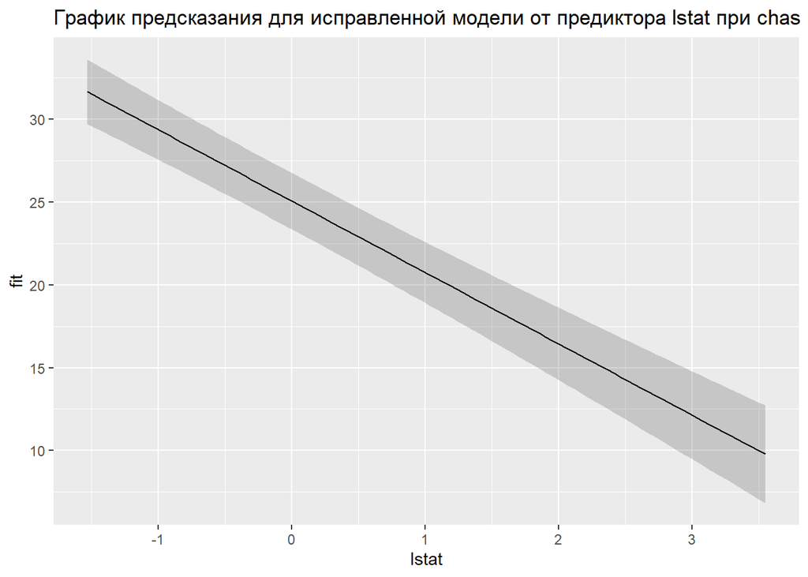

```r
MyData <- data.frame(
     lstat = seq(min(Boston_scale$lstat), max(Boston_scale$lstat), length.out = 100),
     chas = as.factor(1),
     rm = mean(Boston_scale$rm),
     dis = mean(Boston_scale$dis),
     ptratio = mean(Boston_scale$ptratio),
     black = mean(Boston_scale$black),
     lstat = mean(Boston_scale$lstat))

Predictions <- predict(bos_10, newdata = MyData,  interval = 'confidence')
MyData <- data.frame(MyData, Predictions)

Pl_predict <- ggplot(MyData, aes(x = lstat, y = fit)) +
  geom_ribbon(alpha = 0.2, aes(ymin = lwr, ymax = upr)) +
  geom_line() +
  ggtitle("График предсказания для исправленной модели от предиктора lstat при chas = 1")
Pl_predict
```

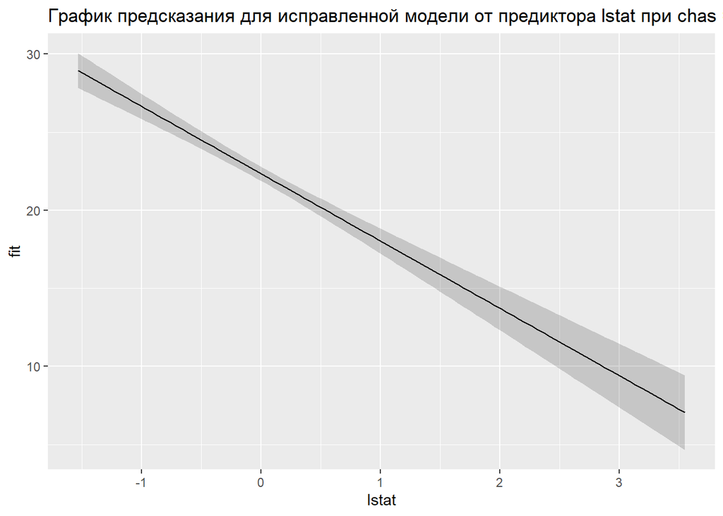

```r
MyData <- data.frame(
     lstat = seq(min(Boston_scale$lstat), max(Boston_scale$lstat), length.out = 100),
     chas = as.factor(0),
     rm = mean(Boston_scale$rm),
     dis = mean(Boston_scale$dis),
     ptratio = mean(Boston_scale$ptratio),
     black = mean(Boston_scale$black),
     lstat = mean(Boston_scale$lstat))

Predictions <- predict(bos_10, newdata = MyData,  interval = 'confidence')
MyData <- data.frame(MyData, Predictions)

Pl_predict <- ggplot(MyData, aes(x = lstat, y = fit)) +
  geom_ribbon(alpha = 0.2, aes(ymin = lwr, ymax = upr)) +
  geom_line() +
  ggtitle("График предсказания для исправленной модели от предиктора lstat при chas = 0")
Pl_predict
```